# BST223 Final

Shutong Gu

2/28/2024

```r
yeast <- read.table("~/Desktop/Data/BST223/yeast/yeast.data")
yeast[yeast$V6 == 1,]
```

```
##              V1   V2   V3   V4   V5 V6 V7   V8   V9 V10
## 220  CYPD_YEAST 0.78 0.74 0.58 0.25  1  0 0.53 0.22 ERL
## 305  EUG1_YEAST 0.77 0.80 0.51 0.40  1  0 0.54 0.22 ERL
## 307  LCF2_YEAST 0.35 0.46 0.49 0.15  1  0 0.55 0.35 CYT
## 396  HAP4_YEAST 0.56 0.57 0.63 0.39  1  0 0.59 0.40 NUC
## 489  GR78_YEAST 0.85 0.56 0.33 0.38  1  0 0.55 0.25 ERL
## 501  KIP1_YEAST 0.43 0.52 0.53 0.52  1  0 0.49 0.22 CYT
## 507  KRE5_YEAST 0.86 0.92 0.50 0.37  1  0 0.53 0.32 ERL
## 660  MYS2_YEAST 0.53 0.41 0.50 0.24  1  0 0.47 0.22 CYT
## 708  NU49_YEAST 0.69 0.62 0.49 0.00  1  0 0.47 0.22 NUC
## 740   PDI_YEAST 0.70 0.84 0.49 0.28  1  0 0.58 0.22 ERL
## 765  6P2K_YEAST 0.45 0.41 0.49 0.14  1  0 0.53 0.30 CYT
## 842  PR05_YEAST 0.33 0.21 0.53 0.15  1  0 0.52 0.50 NUC
## 1059 SC20_YEAST 0.46 0.47 0.44 0.18  1  0 0.46 0.22 ME2
## 1078 SED4_YEAST 0.52 0.55 0.39 0.09  1  0 0.55 0.25 ME3
```

```r
colnames(yeast) <- c("Protein_name","mcg","gvh","alm","mit","erl","pox","vac","nuc","localization")
```

```r
table(yeast$localization)
```

```
##
## CYT ERL EXC ME1 ME2 ME3 MIT NUC POX VAC
## 463   5  35  44  51 163 244 429  20  30
```

The number of sample “ERL” is too few compared to other categories. So this localization will be dropped.

```r
yeast[yeast$localization == 'ERL',]
```

```
##     Protein_name  mcg  gvh  alm  mit erl pox  vac  nuc localization
## 220   CYPD_YEAST 0.78 0.74 0.58 0.25   1   0 0.53 0.22          ERL
## 305   EUG1_YEAST 0.77 0.80 0.51 0.40   1   0 0.54 0.22          ERL
## 489   GR78_YEAST 0.85 0.56 0.33 0.38   1   0 0.55 0.25          ERL
## 507   KRE5_YEAST 0.86 0.92 0.50 0.37   1   0 0.53 0.32          ERL
## 740    PDI_YEAST 0.70 0.84 0.49 0.28   1   0 0.58 0.22          ERL
```

```r
index_ER <- as.integer(rownames(yeast[yeast$localization == 'ERL',]))
yeast <- yeast[-index_ER,]
```

```r
table(yeast$localization)
```

```
##
## CYT EXC ME1 ME2 ME3 MIT NUC POX VAC
## 463  35  44  51 163 244 429  20  30
```

We can keep going to merge the “ME” proteins. The ME1,ME2,ME3 are different be their topological structure on the cell membrane. So it will be possible and reasonable to merge them into one single category that will be called “ME”.

```r
library(dplyr)
yeast_merge <- yeast %>%
  mutate(localization = case_when(
    localization %in% c("ME1", "ME2","ME3") ~ "ME",
    TRUE ~ localization
  ))

table(yeast_merge$localization)
```

```
##
## CYT EXC  ME MIT NUC POX VAC
## 463  35 258 244 429  20  30
```

As such, there will be 7 categories for the final data analysis step. They are: CYT – Cytoplasm EXC – Excretion (outside the cell) ME – Cell Membrane MIT – Mitochondria NUC – Nucleus POX – Peroxisome VAC – Vascular

Then we can check the predictors:

```r
summary(yeast_merge)
```

```
##  Protein_name            mcg              gvh             alm
##  Length:1479        Min.   :0.1100   Min.   :0.130   Min.   :0.2100
##  Class :character   1st Qu.:0.4100   1st Qu.:0.420   1st Qu.:0.4600
##  Mode  :character   Median :0.4800   Median :0.490   Median :0.5100
##                     Mean   :0.4991   Mean   :0.499   Mean   :0.5001
##                     3rd Qu.:0.5700   3rd Qu.:0.570   3rd Qu.:0.5500
##                     Max.   :1.0000   Max.   :1.000   Max.   :1.0000
##       mit              erl             pox                vac
##  Min.   :0.0000   Min.   :0.500   Min.   :0.000000   Min.   :0.0000
##  1st Qu.:0.1700   1st Qu.:0.500   1st Qu.:0.000000   1st Qu.:0.4800
##  Median :0.2200   Median :0.500   Median :0.000000   Median :0.5100
##  Mean   :0.2609   Mean   :0.503   Mean   :0.007525   Mean   :0.4997
##  3rd Qu.:0.3200   3rd Qu.:0.500   3rd Qu.:0.000000   3rd Qu.:0.5300
##  Max.   :1.0000   Max.   :1.000   Max.   :0.830000   Max.   :0.7300
##       nuc         localization
##  Min.   :0.0000   Length:1479
##  1st Qu.:0.2200   Class :character
##  Median :0.2200   Mode  :character
##  Mean   :0.2763
##  3rd Qu.:0.3000
##  Max.   :1.0000
```

The erl can be treated as indicator or binary variable since it indicates the presence of “HDEL” motifs in the protein sequences.

```r
yeast_merge$erl <- as.factor(yeast$erl)
table(yeast_merge$erl)
```

```
##
##  0.5    1
## 1470    9
```

```r
table(yeast_merge[yeast_merge$erl==1,10])
```

```
##
## CYT  ME NUC
##   4   2   3
```

Including Plots

```r
library(ggplot2)
```

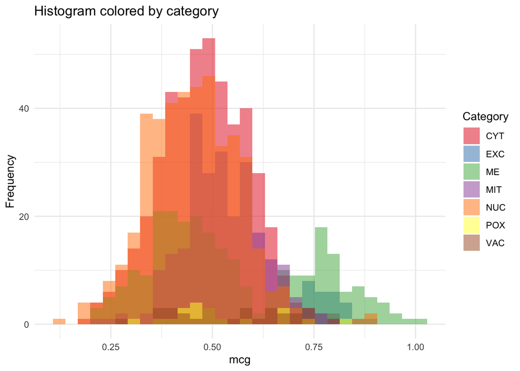

```r
ggplot(yeast_merge, aes(x = mcg, fill = localization)) +
  geom_histogram(position = "identity", alpha = 0.5, bins = 30) +
  scale_fill_brewer(palette = "Set1") + # Optional: Use a color palette for better visuals
  theme_minimal() + # Optional: Apply a minimal theme
  labs(title = "Histogram colored by category",
       x = "mcg",
       y = "Frequency",
       fill = "Category")
```

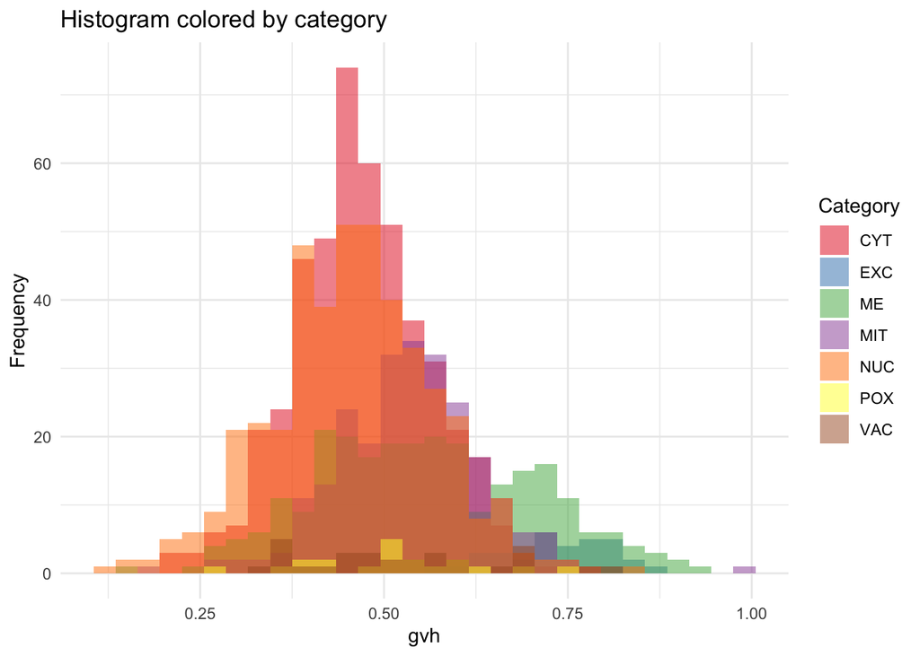

```r
ggplot(yeast_merge, aes(x = gvh, fill = localization)) +
  geom_histogram(position = "identity", alpha = 0.5, bins = 30) +
  scale_fill_brewer(palette = "Set1") + # Optional: Use a color palette for better visuals
  theme_minimal() + # Optional: Apply a minimal theme
  labs(title = "Histogram colored by category",
       x = "gvh",
       y = "Frequency",
       fill = "Category")
```

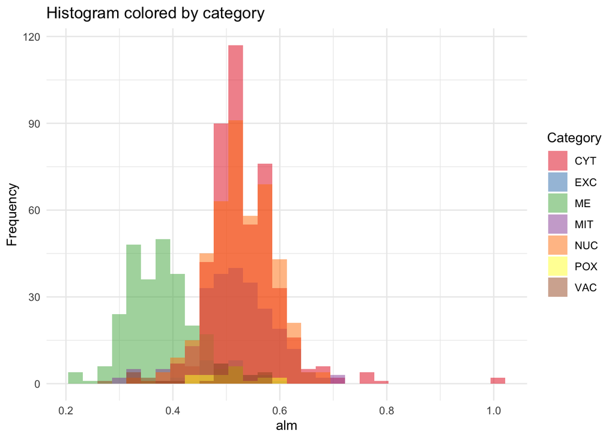

```r
ggplot(yeast_merge, aes(x = alm, fill = localization)) +
  geom_histogram(position = "identity", alpha = 0.5, bins = 30) +
  scale_fill_brewer(palette = "Set1") + # Optional: Use a color palette for better visuals
  theme_minimal() + # Optional: Apply a minimal theme
  labs(title = "Histogram colored by category",
       x = "alm",
       y = "Frequency",
       fill = "Category")
```

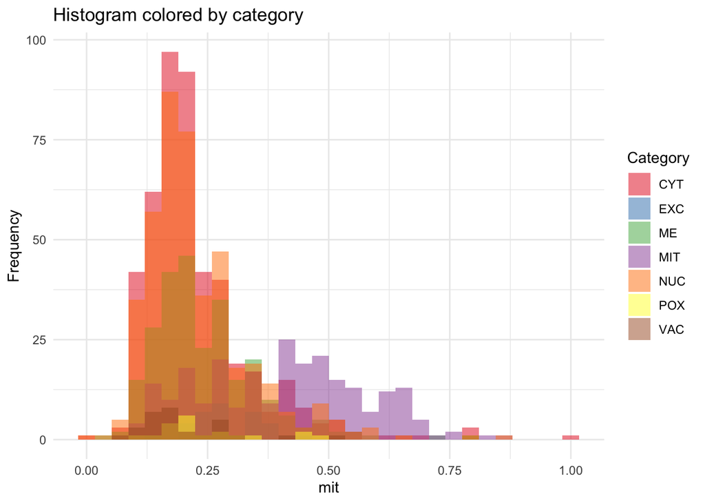

```r
ggplot(yeast_merge, aes(x = mit, fill = localization)) +
  geom_histogram(position = "identity", alpha = 0.5, bins = 30) +
  scale_fill_brewer(palette = "Set1") + # Optional: Use a color palette for better visuals
  theme_minimal() + # Optional: Apply a minimal theme
  labs(title = "Histogram colored by category",
       x = "mit",
       y = "Frequency",
       fill = "Category")
```

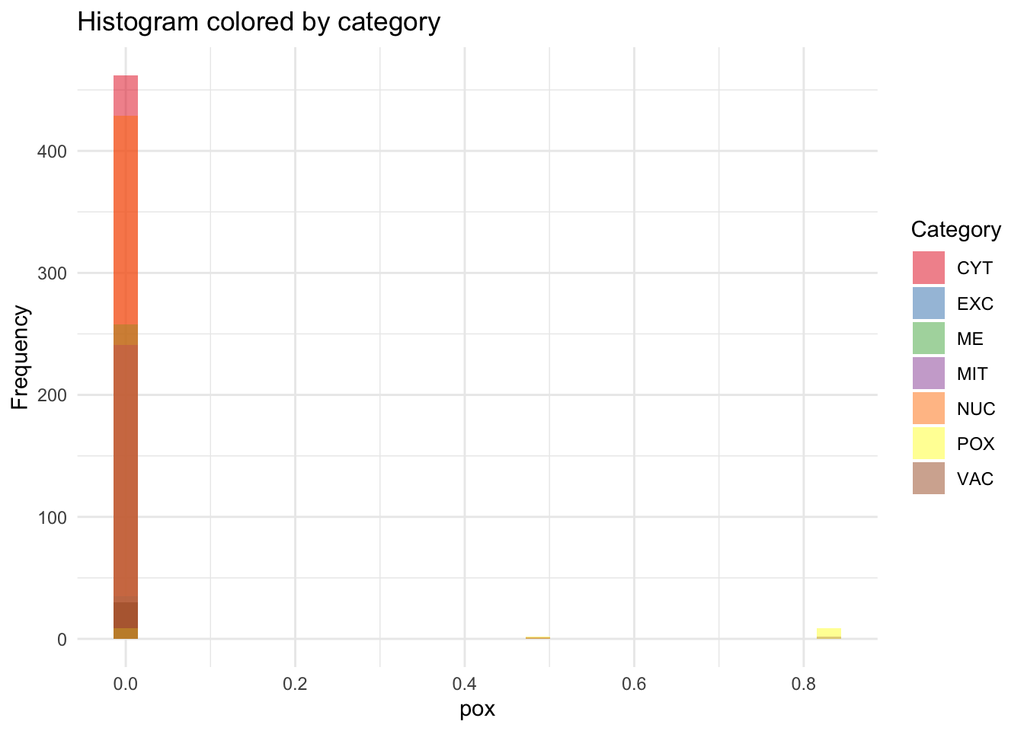

```r
ggplot(yeast_merge, aes(x = pox, fill = localization)) +
  geom_histogram(position = "identity", alpha = 0.5, bins = 30) +
  scale_fill_brewer(palette = "Set1") + # Optional: Use a color palette for better visuals
  theme_minimal() + # Optional: Apply a minimal theme
  labs(title = "Histogram colored by category",
       x = "pox",
       y = "Frequency",
       fill = "Category")
```

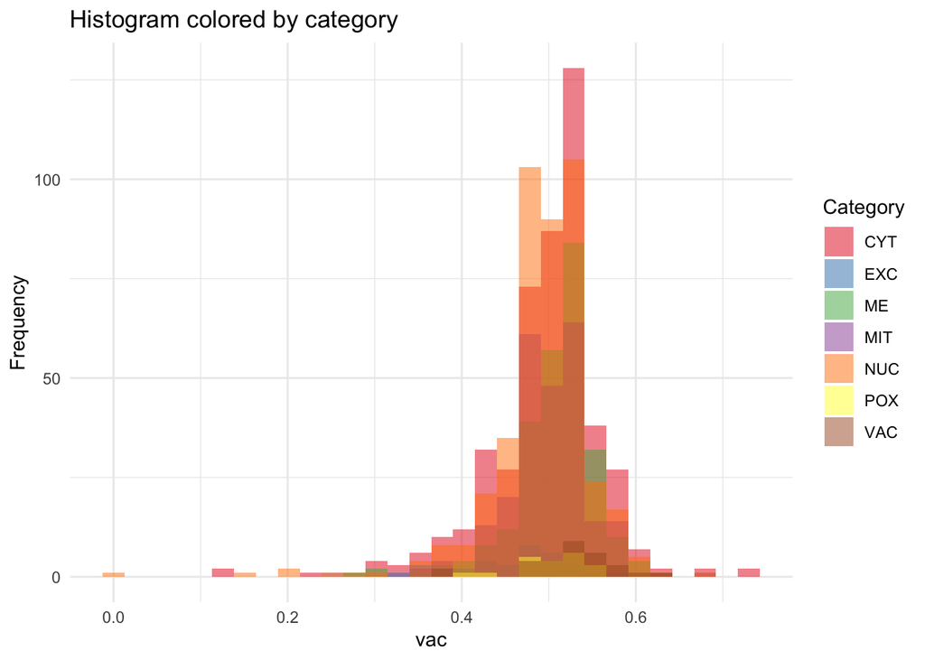

```r
ggplot(yeast_merge, aes(x = vac, fill = localization)) +
  geom_histogram(position = "identity", alpha = 0.5, bins = 30) +
  scale_fill_brewer(palette = "Set1") + # Optional: Use a color palette for better visuals
  theme_minimal() + # Optional: Apply a minimal theme
  labs(title = "Histogram colored by category",
       x = "vac",
       y = "Frequency",
       fill = "Category")
```

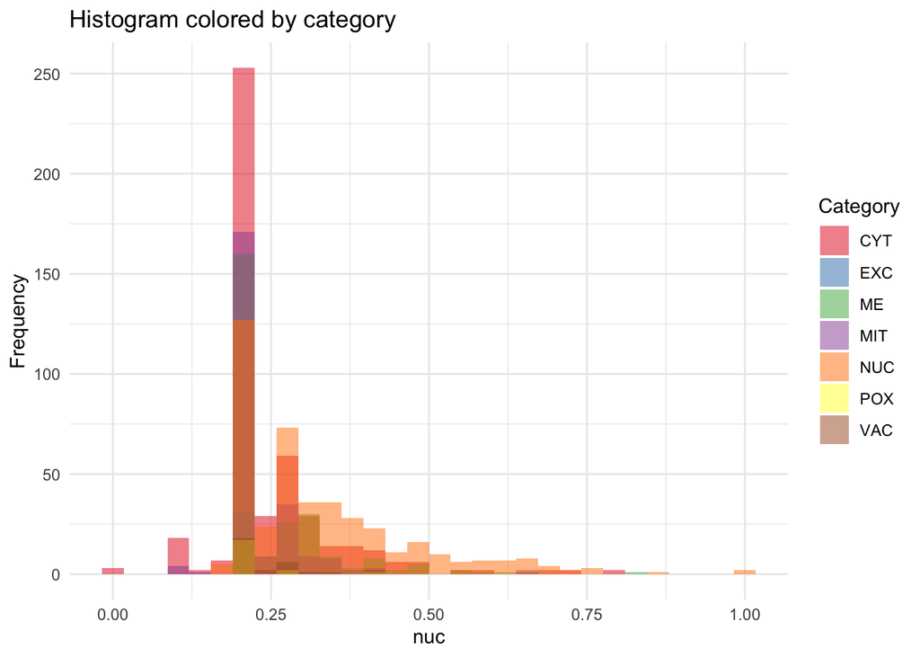

```r
ggplot(yeast_merge, aes(x = nuc, fill = localization)) +
  geom_histogram(position = "identity", alpha = 0.5, bins = 30) +
  scale_fill_brewer(palette = "Set1") + # Optional: Use a color palette for better visuals
  theme_minimal() + # Optional: Apply a minimal theme
  labs(title = "Histogram colored by category",
       x = "nuc",
       y = "Frequency",
       fill = "Category")
```

```r
table(yeast_merge[yeast$pox==0.5,10])
```

```
##
## CYT MIT POX
##   1   1   2
```

```r
table(yeast_merge[yeast$pox==0.83,10])
```

```
##
## MIT POX
##   2   9
```

Set MIT to be the baseline:

```r
yeast_merge$localization <- as.factor(yeast_merge$localization)
levels(yeast_merge$localization)
```

```
## [1] "CYT" "EXC" "ME"  "MIT" "NUC" "POX" "VAC"
```

```r
yeast_merge$localization <- relevel(yeast_merge$localization, ref = "MIT")
levels(yeast_merge$localization)
```

```
## [1] "MIT" "CYT" "EXC" "ME"  "NUC" "POX" "VAC"
```

Set up the Baseline odds model using “nnet” package:

```r
model_bo <- multinom(localization ~ ., data = yeast_merge[,-1])
summary(model_bo,digit=3)
```

```
## Call:
## multinom(formula = localization ~ ., data = yeast_merge[, -1])
##
## Coefficients:
##     (Intercept)    mcg   gvh    alm    mit   erl1    pox    vac   nuc
## CYT       3.621 -0.204 -4.79   4.61  -8.87 13.590  -3.99  -2.59  4.34
## EXC      -0.751  8.476  8.41  -0.73  -8.32 -1.272 -15.31 -14.57 -7.08
## ME       16.824  3.130 -1.04 -32.41  -8.36 14.160 -17.57  -4.98  6.65
## NUC       4.446 -1.885 -4.94   3.56  -8.64 13.225 -26.31  -5.31 10.67
## POX       4.879  2.151 -2.51  -3.85  -6.65 -0.624   5.73  -6.09 -3.44
## VAC       4.511  3.235 -2.94 -12.42 -12.26 -1.921 -17.30   3.90  2.82
##
## Std. Errors:
##     (Intercept)   mcg  gvh  alm   mit     erl1      pox  vac  nuc
## CYT        1.47 0.883 1.01 1.52 0.714 5.12e-01 2.16e+00 1.71 1.44
## EXC        3.35 2.093 2.43 3.72 2.381 3.27e-07 3.01e-05 3.45 5.89
## ME         2.02 1.120 1.26 2.34 1.108 7.41e-01 2.01e-05 2.72 1.74
## NUC        1.52 0.935 1.06 1.59 0.752 5.81e-01 1.31e-05 1.79 1.41
## POX        4.88 2.764 3.18 5.10 2.577 2.79e-07 1.10e+00 5.58 6.35
## VAC        3.05 1.804 2.13 3.16 2.409 2.22e-07 3.08e-05 4.27 3.35
##
## Residual Deviance: 2967.542
## AIC: 3075.542
```

```r
coefficients <- summary(model_bo)$coefficients / summary(model_bo)$standard.errors

# Calculate p-values
p_values <- 2 * (1 - pnorm(abs(coefficients)))

# Displaying the p-values
print(p_values, digit=3)
```

```
##     (Intercept)      mcg      gvh      alm      mit erl1      pox      vac
## CYT     0.01383 8.17e-01 2.05e-06 2.39e-03 0.00e+00    0 6.42e-02 1.28e-01
## EXC     0.82257 5.14e-05 5.49e-04 8.44e-01 4.79e-04    0 0.00e+00 2.42e-05
## ME      0.00000 5.18e-03 4.12e-01 0.00e+00 4.62e-14    0 0.00e+00 6.70e-02
## NUC     0.00355 4.39e-02 2.88e-06 2.56e-02 0.00e+00    0 0.00e+00 3.04e-03
## POX     0.31699 4.36e-01 4.30e-01 4.50e-01 9.82e-03    0 2.04e-07 2.76e-01
## VAC     0.13860 7.29e-02 1.67e-01 8.58e-05 3.59e-07    0 0.00e+00 3.61e-01
##          nuc
## CYT 2.53e-03
## EXC 2.29e-01
## ME  1.34e-04
## NUC 3.35e-14
## POX 5.88e-01
## VAC 4.01e-01
```

Calculate th pearson residuals:

```r
obslabel = cbind(yeast_merge$localization=="MIT",yeast_merge$localization=="CYT", yeast_merge$localization=="EXC", yeast_merge$localization=="ME",yeast_merge$localization=="NUC",yeast_merge$localization=="POX",yeast_merge$localization=="VAC") * 1
```

```r
prd_prob_bo2 = fitted(model_bo)

fitted_m = sapply(2:(ncol(obslabel)), function(m){
  fit_m <- prd_prob_bo2[rowSums(obslabel[,c(1,m)]) > 0,c(1,m)]
  fit_m <- fit_m[,2] / rowSums(fit_m)
})

resP.bo <- sapply(2:ncol(obslabel), function(m) {
  # baseline is column 1 here
  # otherwise you should replace "1" with the corresponding index and adjust the range of "m" accordingly
  obs_m <- obslabel[rowSums(obslabel[,c(1,m)]) > 0, m]
  fit_m <- prd_prob_bo2[rowSums(obslabel[,c(1,m)]) > 0,c(1,m)]
  fit_m <- fit_m[,2] / rowSums(fit_m)
  (obs_m - fit_m) / sqrt(fit_m * (1 - fit_m))
})


# plot
par(mfrow=c(2,2))

plot(fitted_m[[1]], resP.bo[[1]], xlab="Fitted probability for class CYT vs MIT", ylab="Pearson residual",
     sub = "spar = 0.9")
lines(smooth.spline(x = fitted_m[[1]], y = resP.bo[[1]], spar=0.9), col=2); abline(h=0,lty=2)
head(sort(resP.bo[[1]],decreasing = TRUE))
```

```
##       502       180       676      1447       184      1091
## 14.265409  2.920098  2.784488  2.702556  2.397971  2.287058
```

```r
plot(fitted_m[[2]], resP.bo[[2]], xlab="Fitted probability for class EXC vs MIT", ylab="Pearson residual",
     sub = "spar = 1.5",ylim=c(-10,10))
lines(smooth.spline(x = fitted_m[[2]], y = resP.bo[[2]], spar=1.5), col=2); abline(h=0,lty=2)
head(sort(resP.bo[[2]],decreasing = TRUE))
```

```
##        48      1186       579      1143       664       662
## 10.285745  6.442617  4.244758  3.322867  2.256841  1.677867
```

```r
plot(fitted_m[[3]], resP.bo[[3]], xlab="Fitted probability for class ME vs MIT", ylab="Pearson residual",
     sub = "spar = 0.9")
lines(smooth.spline(x = fitted_m[[3]], y = resP.bo[[3]], spar=0.9), col=2); abline(h=0,lty=2)
head(sort(resP.bo[[3]],decreasing = TRUE))
```

```
##       506       364        47       513      1430      1108
## 20.669287  9.988334  7.491467  4.711071  4.214064  3.318413
```

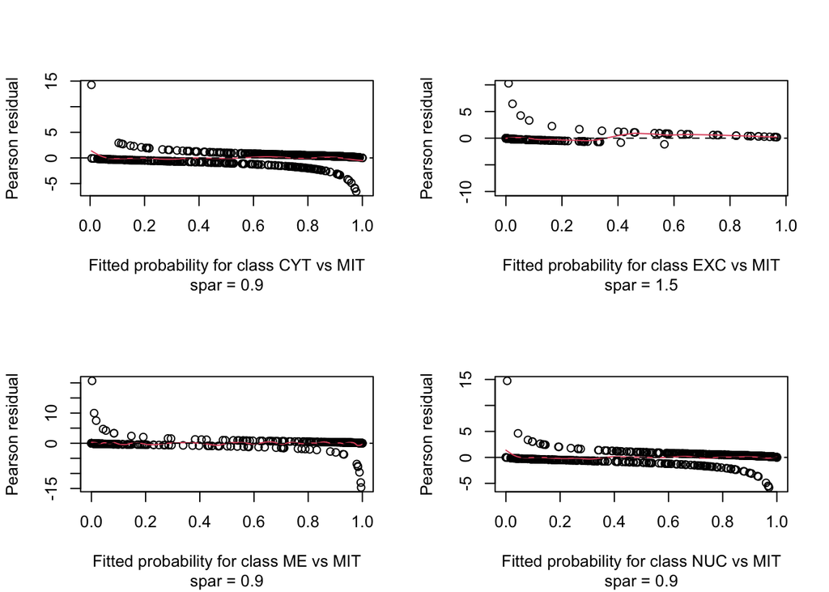

```r
plot(fitted_m[[4]], resP.bo[[4]], xlab="Fitted probability for class NUC vs MIT", ylab="Pearson residual",
     sub = "spar = 0.9")
lines(smooth.spline(x = fitted_m[[4]], y = resP.bo[[4]], spar=0.9), col=2); abline(h=0,lty=2)
```

```r
head(sort(resP.bo[[4]],decreasing = TRUE))
```

```
##      1455       158       924       696       536       681
## 14.735808  4.629778  3.364722  3.046897  3.024698  2.628688
```

```r
plot(fitted_m[[5]], resP.bo[[5]], xlab="Fitted probability for class POX vs MIT", ylab="Pearson residual",
     sub = "spar = 0.9")
lines(smooth.spline(x = fitted_m[[5]], y = resP.bo[[5]], spar=0.9), col=2); abline(h=0,lty=2)
head(sort(resP.bo[[5]],decreasing = TRUE))
```

```
##     1462      728      727      729      813      321
## 7.372359 5.540839 5.376623 4.475676 4.445421 3.549761
```

```
##       821      1278       749      1085       820      1343
## 13.086205  4.266913  3.672307  3.591050  3.460151  3.275214
```

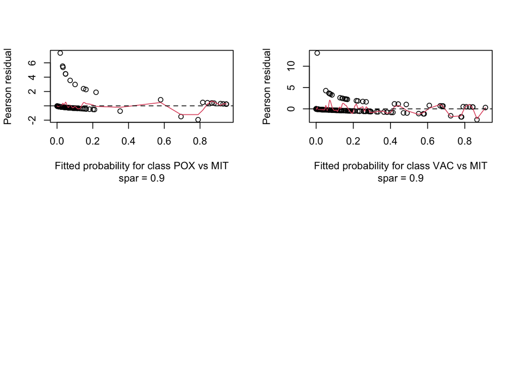

```r
plot(fitted_m[[6]], resP.bo[[6]], xlab="Fitted probability for class VAC vs MIT", ylab="Pearson residual",
     sub = "spar = 0.9")
lines(smooth.spline(x = fitted_m[[6]], y = resP.bo[[6]], spar=0.9), col=2); abline(h=0,lty=2)
head(sort(resP.bo[[6]],decreasing = TRUE))
```

```r
#Model1
model_bo$fitted.values[502,]
```

```
##          MIT          CYT          EXC           ME          NUC          POX
## 0.1137658195 0.4954019022 0.0009415245 0.0028363948 0.3754783409 0.0045285333
##          VAC
## 0.0070474848
```

```r
#Model2
model_bo$fitted.values[48,]
```

```
##         MIT         CYT         EXC          ME         NUC         POX
## 0.151018465 0.493590114 0.001427442 0.015913431 0.315982340 0.010585849
##         VAC
## 0.011482359
```

```r
model_bo$fitted.values[1186,]
```

```
##          MIT          CYT          EXC           ME          NUC          POX
## 4.493089e-03 5.419560e-03 9.192593e-07 9.693848e-01 1.801639e-02 1.555924e-04
##          VAC
## 2.529660e-03
```

```r
#Model3
model_bo$fitted.values[506,]
```

```
##          MIT          CYT          EXC           ME          NUC          POX
## 0.0310351945 0.4485275660 0.0003958465 0.0076851933 0.4985430487 0.0026831737
##          VAC
## 0.0111299773
```

```r
model_bo$fitted.values[364,]
```

```
##         MIT         CYT         EXC          ME         NUC         POX
## 0.079887660 0.531451936 0.001434263 0.025075846 0.316983855 0.006717344
##         VAC
## 0.038449098
```

```r
model_bo$fitted.values[47,]
```

```
##         MIT         CYT         EXC          ME         NUC         POX
## 0.465354562 0.148580518 0.206378020 0.008291826 0.164238535 0.005638378
##         VAC
## 0.001518161
```

```r
#Model4
model_bo$fitted.values[1455,]
```

```
##          MIT          CYT          EXC           ME          NUC          POX
## 2.406829e-03 5.902939e-02 8.199627e-07 4.725377e-02 8.890935e-01 3.895819e-05
##          VAC
## 2.176751e-03
```

```r
#Model5
model_bo$fitted.values[1462,]
```

```
##          MIT          CYT          EXC           ME          NUC          POX
## 1.663318e-03 1.830592e-02 6.082038e-06 9.358470e-01 1.721060e-02 7.997938e-04
##          VAC
## 2.616729e-02
```

```r
model_bo$fitted.values[728,]
```

```
##         MIT         CYT         EXC          ME         NUC         POX
## 0.712174511 0.161883429 0.003165946 0.007289366 0.107363614 0.005371585
##         VAC
## 0.002751549
```

```r
model_bo$fitted.values[727,]
```

```
##         MIT         CYT         EXC          ME         NUC         POX
## 0.014480422 0.047119344 0.001250766 0.851985407 0.028337158 0.003447079
##         VAC
## 0.053379824
```

```r
#Model6
model_bo$fitted.values[821,]
```

```
##         MIT         CYT         EXC          ME         NUC         POX
## 0.096492898 0.568635847 0.003249672 0.005454888 0.304767692 0.008358381
##         VAC
## 0.013040621
```

```r
abnormal <- c('502','48','1186','506','364','47','1455','1462','728','727','821')
```

Removing those points and test if the model would be strongly affected:

```r
abnormal_proteins <- yeast_merge[rownames(yeast_merge) %in% abnormal,]
p502 <- abnormal_proteins[rownames(abnormal_proteins) == "502",]

yeast_merged_rr <- yeast_merge[!(rownames(yeast_merge) %in% abnormal),]
```

Refit the model:

```r
library(nnet)
model_bo_rr <- multinom(localization ~ . , data = yeast_merged_rr[,-c(1,11)])
summary(model_bo_rr,digit=3)
```

```
## Call:
## multinom(formula = localization ~ ., data = yeast_merged_rr[,
##     -c(1, 11)])
##
## Coefficients:
##     (Intercept)    mcg   gvh     alm    mit   erl1    pox    vac   nuc
## CYT        4.29 -0.330 -5.10   4.279  -9.42 15.155  -3.58  -2.88  4.43
## EXC       -2.30  8.852 10.36   0.833  -9.23 -1.136 -16.25 -16.59 -5.88
## ME        18.78  2.727 -1.44 -34.639  -9.29 15.766 -19.23  -5.72  6.87
## NUC        5.17 -2.057 -5.26   3.188  -9.22 14.790 -28.52  -5.60 10.78
## POX        7.84  0.632 -4.68  -4.123 -11.36 -0.362   6.59  -6.03 -4.49
## VAC        6.27  2.970 -3.20 -13.869 -14.67 -2.082 -19.05   3.11  3.23
##
## Std. Errors:
##     (Intercept)   mcg  gvh  alm   mit     erl1      pox  vac  nuc
## CYT        1.52 0.895 1.03 1.55 0.739 5.17e-01 2.19e+00 1.74 1.45
## EXC        3.90 2.272 2.71 4.23 2.865 1.43e-07 2.07e-05 3.81 6.48
## ME         2.12 1.146 1.30 2.50 1.178 7.54e-01 8.18e-06 2.81 1.76
## NUC        1.57 0.948 1.08 1.63 0.778 5.85e-01 6.42e-06 1.83 1.41
## POX        5.77 3.390 3.93 5.94 3.922 1.83e-07 1.29e+00 6.62 7.77
## VAC        3.18 1.831 2.19 3.30 2.728 6.12e-08 1.42e-05 4.44 3.37
##
## Residual Deviance: 2844.327
## AIC: 2952.327
```

```r
coefficients_rr <- summary(model_bo_rr)$coefficients / summary(model_bo_rr)$standard.errors

# Calculate p-values
p_values_rr <- 2 * (1 - pnorm(abs(coefficients_rr)))

# Displaying the p-values
print(p_values,digits = 3)
```

```
##     (Intercept)      mcg      gvh      alm      mit erl1      pox      vac
## CYT     0.01383 8.17e-01 2.05e-06 2.39e-03 0.00e+00    0 6.42e-02 1.28e-01
## EXC     0.82257 5.14e-05 5.49e-04 8.44e-01 4.79e-04    0 0.00e+00 2.42e-05
## ME      0.00000 5.18e-03 4.12e-01 0.00e+00 4.62e-14    0 0.00e+00 6.70e-02
## NUC     0.00355 4.39e-02 2.88e-06 2.56e-02 0.00e+00    0 0.00e+00 3.04e-03
## POX     0.31699 4.36e-01 4.30e-01 4.50e-01 9.82e-03    0 2.04e-07 2.76e-01
## VAC     0.13860 7.29e-02 1.67e-01 8.58e-05 3.59e-07    0 0.00e+00 3.61e-01
##          nuc
## CYT 2.53e-03
## EXC 2.29e-01
## ME  1.34e-04
## NUC 3.35e-14
## POX 5.88e-01
## VAC 4.01e-01
```

```r
print(p_values_rr, digit=3)
```

```
##     (Intercept)      mcg      gvh      alm      mit erl1      pox      vac
## CYT    0.004643 7.12e-01 7.31e-07 0.005763 0.00e+00    0 1.02e-01 9.70e-02
## EXC    0.555173 9.78e-05 1.32e-04 0.843872 1.28e-03    0 0.00e+00 1.36e-05
## ME     0.000000 1.73e-02 2.68e-01 0.000000 3.11e-15    0 0.00e+00 4.18e-02
## NUC    0.000999 3.00e-02 1.02e-06 0.050641 0.00e+00    0 0.00e+00 2.14e-03
## POX    0.174465 8.52e-01 2.34e-01 0.487733 3.77e-03    0 3.32e-07 3.62e-01
## VAC    0.048989 1.05e-01 1.44e-01 0.000027 7.53e-08    0 0.00e+00 4.85e-01
##          nuc
## CYT 2.19e-03
## EXC 3.64e-01
## ME  9.54e-05
## NUC 2.46e-14
## POX 5.63e-01
## VAC 3.38e-01
```

Comparing two model output:

```r
print(coefficients, digit=3)
```

```
##     (Intercept)    mcg    gvh     alm    mit      erl1       pox    vac    nuc
## CYT       2.462 -0.232 -4.748   3.037 -12.42  2.65e+01 -1.85e+00 -1.520  3.020
## EXC      -0.224  4.049  3.456  -0.196  -3.49 -3.90e+06 -5.09e+05 -4.222 -1.203
## ME        8.332  2.796 -0.821 -13.835  -7.54  1.91e+01 -8.76e+05 -1.832  3.818
## NUC       2.916 -2.015 -4.679   2.232 -11.49  2.28e+01 -2.01e+06 -2.964  7.584
## POX       1.001  0.778 -0.789  -0.755  -2.58 -2.23e+06  5.20e+00 -1.090 -0.542
## VAC       1.481  1.793 -1.381  -3.928  -5.09 -8.64e+06 -5.61e+05  0.913  0.840
```

```r
print(coefficients_rr, digit=3)
```

```
##     (Intercept)    mcg   gvh     alm    mit      erl1       pox    vac    nuc
## CYT        2.83 -0.369 -4.95   2.761 -12.75  2.93e+01 -1.64e+00 -1.660  3.063
## EXC       -0.59  3.896  3.82   0.197  -3.22 -7.96e+06 -7.86e+05 -4.349 -0.908
## ME         8.85  2.379 -1.11 -13.865  -7.89  2.09e+01 -2.35e+06 -2.036  3.902
## NUC        3.29 -2.171 -4.89   1.955 -11.85  2.53e+01 -4.44e+06 -3.070  7.623
## POX        1.36  0.186 -1.19  -0.694  -2.90 -1.97e+06  5.10e+00 -0.912 -0.578
## VAC        1.97  1.622 -1.46  -4.197  -5.38 -3.40e+07 -1.34e+06  0.699  0.959
```

Then we would attempt to use GAM model to solve for any potential unlinearity: First, we can use stepwise function to select the most significant predictors to reduce the complexity of model:

```r
library(MASS)
```

Creating Sub models using logistic regression:

```r
data_submodel_CYT <- yeast_merge
data_submodel_CYT$category_numeric <- ifelse(data_submodel_CYT$localization == "CYT", 1, 0)
submodel_CYT <- glm(category_numeric~.,family="binomial",data=data_submodel_CYT[,-c(1,10)])
summary(submodel_CYT)
```

```
##
## Call:
## glm(formula = category_numeric ~ ., family = "binomial", data = data_submodel_CYT[,
##     -c(1, 10)])
##
## Deviance Residuals:
##     Min       1Q   Median       3Q      Max
## -1.8515  -0.8448  -0.5570   1.1388   2.5728
##
## Coefficients:
##             Estimate Std. Error z value Pr(>|z|)
## (Intercept)  -3.3189     0.8456  -3.925 8.67e-05 ***
## mcg           0.0695     0.5715   0.122  0.90320
## gvh          -1.8484     0.6428  -2.875  0.00403 **
## alm           8.1809     0.8515   9.607  < 2e-16 ***
## mit          -3.6377     0.5326  -6.830 8.48e-12 ***
## erl1          0.5140     0.6855   0.750  0.45338
## pox          -3.5606     1.7707  -2.011  0.04435 *
## vac           2.2940     1.0894   2.106  0.03523 *
## nuc          -3.7076     0.6928  -5.352 8.71e-08 ***
## ---
## Signif. codes:  0 '***' 0.001 '**' 0.01 '*' 0.05 '.' 0.1 ' ' 1
##
## (Dispersion parameter for binomial family taken to be 1)
##
##     Null deviance: 1838.5  on 1478  degrees of freedom
## Residual deviance: 1607.3  on 1470  degrees of freedom
## AIC: 1625.3
##
## Number of Fisher Scoring iterations: 5
```

```r
stepAIC(submodel_CYT, trace=FALSE,k = log(nrow(yeast_merge)))
```

```
##
## Call:  glm(formula = category_numeric ~ gvh + alm + mit + pox + nuc,
##     family = "binomial", data = data_submodel_CYT[, -c(1, 10)])
##
## Coefficients:
## (Intercept)          gvh          alm          mit          pox          nuc
##      -2.049       -1.727        7.868       -3.725       -3.543       -3.567
##
## Degrees of Freedom: 1478 Total (i.e. Null);  1473 Residual
## Null Deviance:       1838
## Residual Deviance: 1612  AIC: 1624
```

```r
data_submodel_EXC <- yeast_merge
data_submodel_EXC$category_numeric <- ifelse(data_submodel_CYT$localization == "EXC", 1, 0)
submodel_EXC <- glm(category_numeric~.,family="binomial",data=data_submodel_EXC[,-c(1,10)])
summary(submodel_EXC)
```

```
##
## Call:
## glm(formula = category_numeric ~ ., family = "binomial", data = data_submodel_EXC[,
##     -c(1, 10)])
##
## Deviance Residuals:
##     Min       1Q   Median       3Q      Max
## -2.0323  -0.1176  -0.0535  -0.0229   3.7350
##
## Coefficients:
##             Estimate Std. Error z value Pr(>|z|)
## (Intercept)  -12.512      2.895  -4.321 1.55e-05 ***
## mcg            7.718      1.911   4.039 5.37e-05 ***
## gvh           12.242      2.239   5.469 4.53e-08 ***
## alm            9.832      2.771   3.548 0.000388 ***
## mit           -4.037      2.130  -1.895 0.058057 .
## erl1         -14.299   1713.752  -0.008 0.993343
## pox          -21.948   2220.758  -0.010 0.992114
## vac          -10.118      2.829  -3.576 0.000348 ***
## nuc           -9.564      4.704  -2.033 0.042059 *
## ---
## Signif. codes:  0 '***' 0.001 '**' 0.01 '*' 0.05 '.' 0.1 ' ' 1
##
## (Dispersion parameter for binomial family taken to be 1)
##
##     Null deviance: 331.23  on 1478  degrees of freedom
## Residual deviance: 175.73  on 1470  degrees of freedom
## AIC: 193.73
##
## Number of Fisher Scoring iterations: 17
```

```r
stepAIC(submodel_EXC, trace=FALSE,k = log(nrow(yeast_merge)))
```

```
##
## Call:  glm(formula = category_numeric ~ mcg + gvh + alm + vac, family = "binomial",
##     data = data_submodel_EXC[, -c(1, 10)])
##
## Coefficients:
## (Intercept)          mcg          gvh          alm          vac
##     -15.403        7.290       11.608        9.733       -9.662
##
## Degrees of Freedom: 1478 Total (i.e. Null);  1474 Residual
## Null Deviance:       331.2
## Residual Deviance: 185.2     AIC: 195.2
```

```r
data_submodel_ME <- yeast_merge
data_submodel_ME$category_numeric <- ifelse(data_submodel_ME$localization == "ME", 1, 0)
submodel_ME <- glm(category_numeric~.,family="binomial",data=data_submodel_ME[,-c(1,10)])
summary(submodel_ME)
```

```
##
## Call:
## glm(formula = category_numeric ~ ., family = "binomial", data = data_submodel_ME[,
##     -c(1, 10)])
##
## Deviance Residuals:
##     Min       1Q   Median       3Q      Max
## -2.9435  -0.2866  -0.1366  -0.0409   3.3760
##
## Coefficients:
##              Estimate Std. Error z value Pr(>|z|)
## (Intercept)   12.1478     1.6153   7.520 5.46e-14 ***
## mcg            2.5635     0.9159   2.799  0.00513 **
## gvh            1.1507     1.0310   1.116  0.26436
## alm          -33.0996     1.9864 -16.663  < 2e-16 ***
## mit           -2.3720     0.9471  -2.504  0.01226 *
## erl1           0.9213     1.0604   0.869  0.38494
## pox          -22.6399  1267.9722  -0.018  0.98575
## vac           -0.0186     2.2774  -0.008  0.99348
## nuc           -0.1640     1.0941  -0.150  0.88085
## ---
## Signif. codes:  0 '***' 0.001 '**' 0.01 '*' 0.05 '.' 0.1 ' ' 1
##
## (Dispersion parameter for binomial family taken to be 1)
##
##     Null deviance: 1369.14  on 1478  degrees of freedom
## Residual deviance:  582.91  on 1470  degrees of freedom
## AIC: 600.91
##
## Number of Fisher Scoring iterations: 16
```

```r
stepAIC(submodel_ME, trace=FALSE, k = log(nrow(yeast_merge)))
```

```
##
## Call:  glm(formula = category_numeric ~ mcg + alm + mit, family = "binomial",
##     data = data_submodel_ME[, -c(1, 10)])
##
## Coefficients:
## (Intercept)          mcg          alm          mit
##      12.516        3.155      -33.356       -2.435
##
## Degrees of Freedom: 1478 Total (i.e. Null);  1475 Residual
## Null Deviance:       1369
## Residual Deviance: 588.2     AIC: 596.2
```

```r
data_submodel_NUC <- yeast_merge
data_submodel_NUC$category_numeric <- ifelse(data_submodel_NUC$localization == "NUC", 1, 0)
submodel_NUC <- glm(category_numeric~.,family="binomial",data=data_submodel_NUC[,-c(1,10)])
summary(submodel_NUC)
```

```
##
## Call:
## glm(formula = category_numeric ~ ., family = "binomial", data = data_submodel_NUC[,
##     -c(1, 10)])
##
## Deviance Residuals:
##     Min       1Q   Median       3Q      Max
## -2.7126  -0.7686  -0.4999   0.7920   2.6396
##
## Coefficients:
##              Estimate Std. Error z value Pr(>|z|)
## (Intercept)  -2.51114    0.87046  -2.885 0.003916 **
## mcg          -2.05597    0.62193  -3.306 0.000947 ***
## gvh          -1.67551    0.68276  -2.454 0.014127 *
## alm           6.25366    0.85839   7.285 3.21e-13 ***
## mit          -2.78172    0.54052  -5.146 2.66e-07 ***
## erl1         -0.05489    0.80363  -0.068 0.945544
## pox         -27.30646  869.28659  -0.031 0.974941
## vac          -2.20786    1.12451  -1.963 0.049600 *
## nuc           7.20282    0.68216  10.559  < 2e-16 ***
## ---
## Signif. codes:  0 '***' 0.001 '**' 0.01 '*' 0.05 '.' 0.1 ' ' 1
##
## (Dispersion parameter for binomial family taken to be 1)
##
##     Null deviance: 1781.3  on 1478  degrees of freedom
## Residual deviance: 1451.5  on 1470  degrees of freedom
## AIC: 1469.5
##
## Number of Fisher Scoring iterations: 15
```

```r
stepAIC(submodel_NUC, trace=FALSE, k = log(nrow(yeast_merge)))
```

```
##
## Call:  glm(formula = category_numeric ~ mcg + alm + mit + pox + nuc,
##     family = "binomial", data = data_submodel_NUC[, -c(1, 10)])
##
## Coefficients:
## (Intercept)          mcg          alm          mit          pox          nuc
##      -4.403       -2.854        6.982       -2.723      -27.277        7.136
##
## Degrees of Freedom: 1478 Total (i.e. Null);  1473 Residual
## Null Deviance:       1781
## Residual Deviance: 1462  AIC: 1474
```

```r
data_submodel_POX <- yeast_merge
data_submodel_POX$category_numeric <- ifelse(data_submodel_POX$localization == "POX", 1, 0)
submodel_POX <- glm(category_numeric~.,family="binomial",data=data_submodel_POX[,-c(1,10)])
summary(submodel_POX)
```

```
##
## Call:
## glm(formula = category_numeric ~ ., family = "binomial", data = data_submodel_POX[,
##     -c(1, 10)])
##
## Deviance Residuals:
##     Min       1Q   Median       3Q      Max
## -2.0634  -0.1280  -0.1129  -0.0889   3.1775
##
## Coefficients:
##               Estimate Std. Error z value Pr(>|z|)
## (Intercept)   -3.18675    4.18909  -0.761    0.447
## mcg            1.53851    2.63711   0.583    0.560
## gvh            0.03481    3.02773   0.011    0.991
## alm            0.47409    3.79758   0.125    0.901
## mit           -1.30522    2.47945  -0.526    0.599
## erl1         -12.39232 1279.24934  -0.010    0.992
## pox            8.27452    1.07610   7.689 1.48e-14 ***
## vac           -1.56051    4.97358  -0.314    0.754
## nuc           -7.17961    5.41526  -1.326    0.185
## ---
## Signif. codes:  0 '***' 0.001 '**' 0.01 '*' 0.05 '.' 0.1 ' ' 1
##
## (Dispersion parameter for binomial family taken to be 1)
##
##     Null deviance: 211.86  on 1478  degrees of freedom
## Residual deviance: 123.10  on 1470  degrees of freedom
## AIC: 141.1
##
## Number of Fisher Scoring iterations: 16
```

```r
stepAIC(submodel_POX, trace=FALSE, k = log(nrow(yeast_merge)))
```

```
##
## Call:  glm(formula = category_numeric ~ pox, family = "binomial", data = data_submodel_POX[,
##     -c(1, 10)])
##
## Coefficients:
## (Intercept)          pox
##      -5.049        8.312
##
## Degrees of Freedom: 1478 Total (i.e. Null);  1477 Residual
## Null Deviance:       211.9
## Residual Deviance: 126.5     AIC: 130.5
```

```r
data_submodel_VAC <- yeast_merge
data_submodel_VAC$category_numeric <- ifelse(data_submodel_VAC$localization == "VAC", 1, 0)
submodel_VAC <- glm(category_numeric~.,family="binomial",data=data_submodel_VAC[,-c(1,10)])
summary(submodel_VAC)
```

```
##
## Call:
## glm(formula = category_numeric ~ ., family = "binomial", data = data_submodel_VAC[,
##     -c(1, 10)])
##
## Deviance Residuals:
##     Min       1Q   Median       3Q      Max
## -0.7180  -0.2306  -0.1704  -0.1099   3.2741
##
## Coefficients:
##              Estimate Std. Error z value Pr(>|z|)
## (Intercept)   -5.0960     2.5318  -2.013   0.0441 *
## mcg            2.3879     1.6115   1.482   0.1384
## gvh           -0.1975     1.9334  -0.102   0.9187
## alm           -3.5196     2.1469  -1.639   0.1011
## mit           -5.8710     2.2825  -2.572   0.0101 *
## erl1         -15.0024  2046.0346  -0.007   0.9941
## pox          -24.0889  2429.4109  -0.010   0.9921
## vac            7.8766     3.7899   2.078   0.0377 *
## nuc           -3.5172     2.8500  -1.234   0.2172
## ---
## Signif. codes:  0 '***' 0.001 '**' 0.01 '*' 0.05 '.' 0.1 ' ' 1
##
## (Dispersion parameter for binomial family taken to be 1)
##
##     Null deviance: 293.26  on 1478  degrees of freedom
## Residual deviance: 268.68  on 1470  degrees of freedom
## AIC: 286.68
##
## Number of Fisher Scoring iterations: 17
```

```r
stepAIC(submodel_VAC, trace=FALSE, k = log(nrow(yeast_merge)))
```

```
##
## Call:  glm(formula = category_numeric ~ mit, family = "binomial", data = data_submodel_VAC[,
##     -c(1, 10)])
##
## Coefficients:
## (Intercept)          mit
##      -2.755       -4.942
##
## Degrees of Freedom: 1478 Total (i.e. Null);  1477 Residual
## Null Deviance:       293.3
## Residual Deviance: 285.7     AIC: 289.7
```

```r
library(mgcv)
#Removing one category POX to reduce complexity for GAM
yeast_merge_gam <- yeast_merge[yeast_merge$localization != 'POX',]

table(yeast_merge_gam$localization)
```

```
##
## MIT CYT EXC  ME NUC POX VAC
## 244 463  35 258 429   0  30
```

```r
#sum(yeast_merge_gam$localization=="MIT")

yeast_merge_gam$localization <- as.factor(as.character(yeast_merge_gam$localization))
yeast_merge_gam$localization <- relevel(yeast_merge_gam$localization,ref="MIT")
levels(yeast_merge_gam$localization)
```

```
## [1] "MIT" "CYT" "EXC" "ME"  "NUC" "VAC"
```

```r
yeast_merge_gam$category_numeric <- as.integer(yeast_merge_gam$localization) - 1
str(yeast_merge_gam$category_numeric)
```

```
##  num [1:1459] 0 0 0 4 0 1 0 4 0 1 ...
```

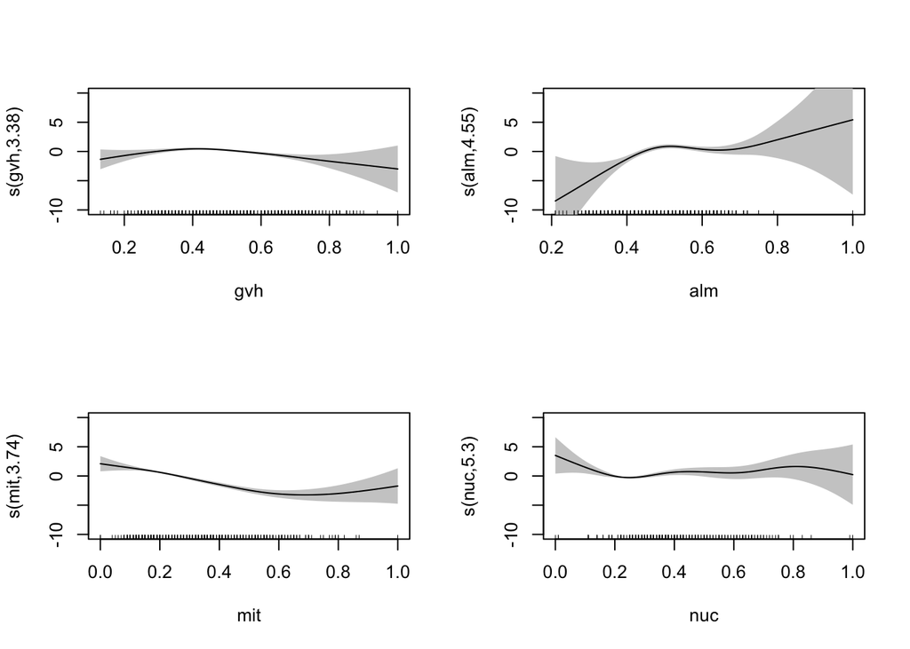

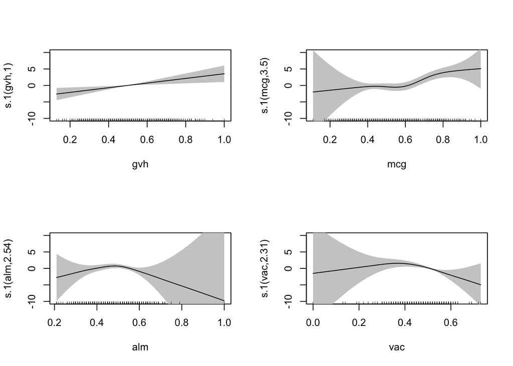

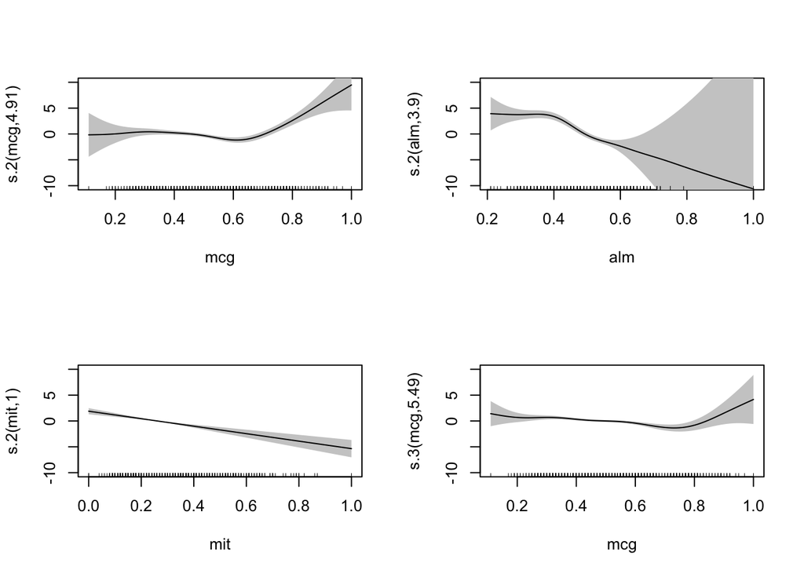

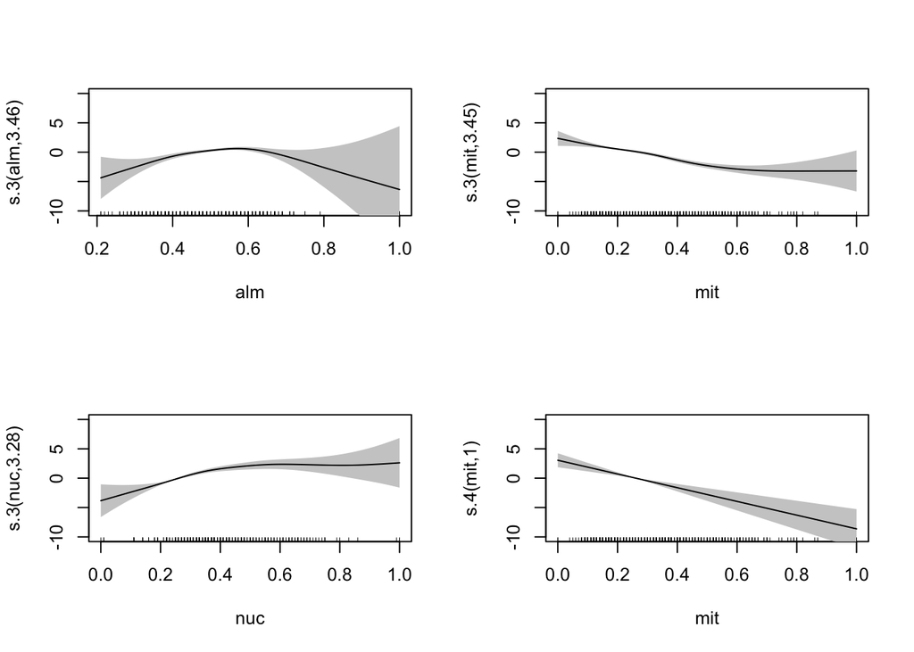

```r
model_bo_gam <- mgcv::gam(list(category_numeric ~ s(gvh)+s(alm)+s(mit)+s(nuc)
                         ,~s(gvh)+s(mcg)+s(alm)+s(vac)
                         ,~s(mcg)+s(alm)+s(mit)
                         ,~s(mcg)+s(alm)+s(mit)+s(nuc)
                         ,~s(mit)),
                         family=multinom(K=5), data=yeast_merge_gam[,-c(1,10)])
par(mfrow=c(2,2))
plot(model_bo_gam,shade=TRUE,ylim = c(-10, 10))
```

```r
summary(model_bo_gam)
```

```
##
## Family: multinom
## Link function:
##
## Formula:
## category_numeric ~ s(gvh) + s(alm) + s(mit) + s(nuc)
## ~s(gvh) + s(mcg) + s(alm) + s(vac)
## ~s(mcg) + s(alm) + s(mit)
## ~s(mcg) + s(alm) + s(mit) + s(nuc)
## ~s(mit)
##
## Parametric coefficients:
##               Estimate Std. Error z value Pr(>|z|)
## (Intercept)     0.4345     0.1759   2.470   0.0135 *
## (Intercept).1  -4.2556     0.5820  -7.312 2.64e-13 ***
## (Intercept).2  -1.4397     0.2913  -4.943 7.71e-07 ***
## (Intercept).3   0.5866     0.1242   4.724 2.31e-06 ***
## (Intercept).4  -1.9067     0.2380  -8.012 1.13e-15 ***
## ---
## Signif. codes:  0 '***' 0.001 '**' 0.01 '*' 0.05 '.' 0.1 ' ' 1
##
## Approximate significance of smooth terms:
##            edf Ref.df  Chi.sq  p-value
## s(gvh)   3.378  4.212  30.536 6.58e-06 ***
## s(alm)   4.548  5.478  32.343 1.32e-05 ***
## s(mit)   3.740  4.667 172.660  < 2e-16 ***
## s(nuc)   5.301  6.337  22.106  0.00199 **
## s.1(gvh) 1.001  1.002   8.031  0.00460 **
## s.1(mcg) 3.497  4.321  33.469 1.96e-06 ***
## s.1(alm) 2.537  3.173   5.092  0.17617
## s.1(vac) 2.314  2.931  13.601  0.00324 **
## s.2(mcg) 4.914  5.903  60.235  < 2e-16 ***
## s.2(alm) 3.903  4.726 135.783  < 2e-16 ***
## s.2(mit) 1.001  1.001  40.747  < 2e-16 ***
## s.3(mcg) 5.493  6.478  38.621  < 2e-16 ***
## s.3(alm) 3.455  4.242  28.435 1.65e-05 ***
## s.3(mit) 3.450  4.332 138.094  < 2e-16 ***
## s.3(nuc) 3.285  4.092  93.231  < 2e-16 ***
## s.4(mit) 1.000  1.000  26.470 1.10e-06 ***
## ---
## Signif. codes:  0 '***' 0.001 '**' 0.01 '*' 0.05 '.' 0.1 ' ' 1
##
## Deviance explained = 39.2%
## -REML = 1166.2  Scale est. = 1         n = 1459
```